# Checkpoint4 AD1 - Análise dos gastos dos deputados federais

18 de julho de 2016

# Nesta análise, iremos dar a resposta a duas perguntas feitas sobre os gastos dos nossos deputados federais. OBS: Os gastos analisados são de janeiro de 2016 a meados de junho.

## 1ª Pergunta: Sabendo o deputado que mais gasta com combustível, quantas viagens ele daria do Oiapoque ao Chuí com esses gastos?

### Primeiramente, vamos ampliar a pergunta e ver quem são os 30 deputados federais que mais gastam sua cota com combustíveis e lubrificantes (e não apenas o primeiro):

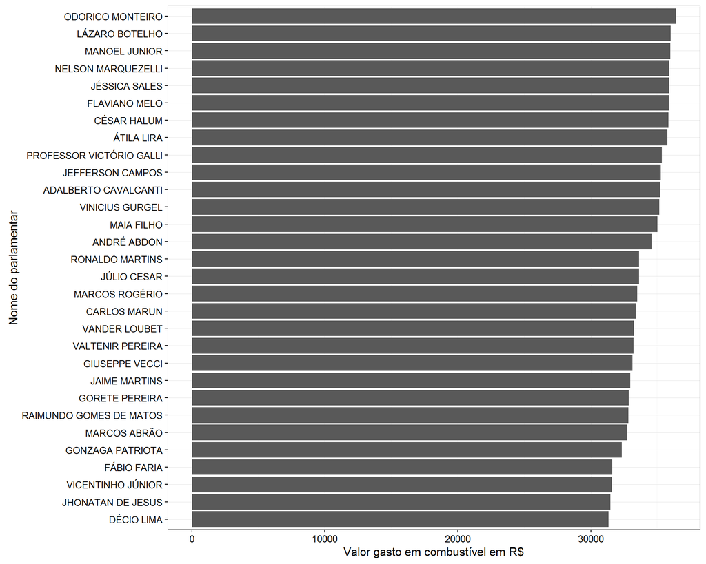

### Sabendo que a distância de carro do Oiapoque ao Chuí é de 5577Km, e que o preço médio da gasolina no DF é de R$3,75 (no mês de maio de 2016) e que o carro faça apenas 10km/l chegamos ao seguinte número de idas do Oiapoque ao Chuí dos 30 deputados que mais gastam combustíveis e lubrificantes:

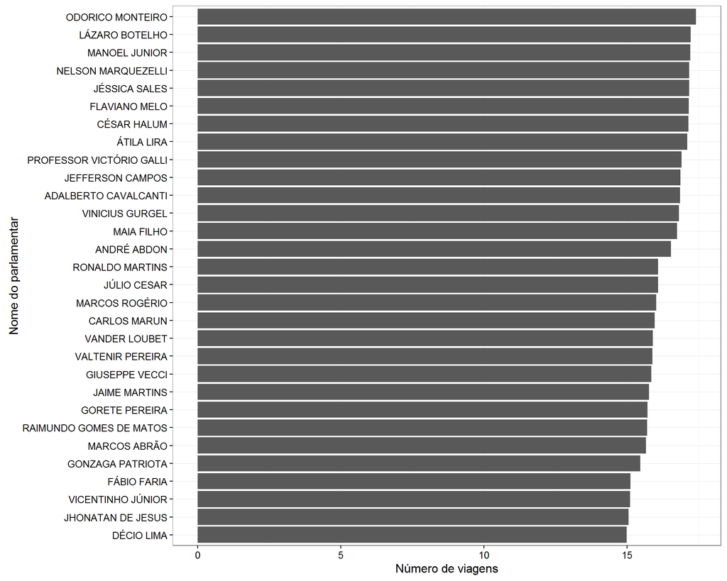

### E se somarmos o gasto da referida cota de todos os deputados federais, quantas voltas ao mundo seria possível realizar? Seria possível dar pouco mais de 565 voltas no mundo! Obs: Uma volta na terra sobre a linha do Equador possui 40.075Km

```
##   ((sum(vlrLiquido)/3.75) * 10)/40075
## 1                            565.4034
```

## 2ª Pergunta: É possível determinar o posicionamento político de um partido através das revistas/jornais que assinam?

### Primeiro, quais são as 20 publicações mais assinadas?

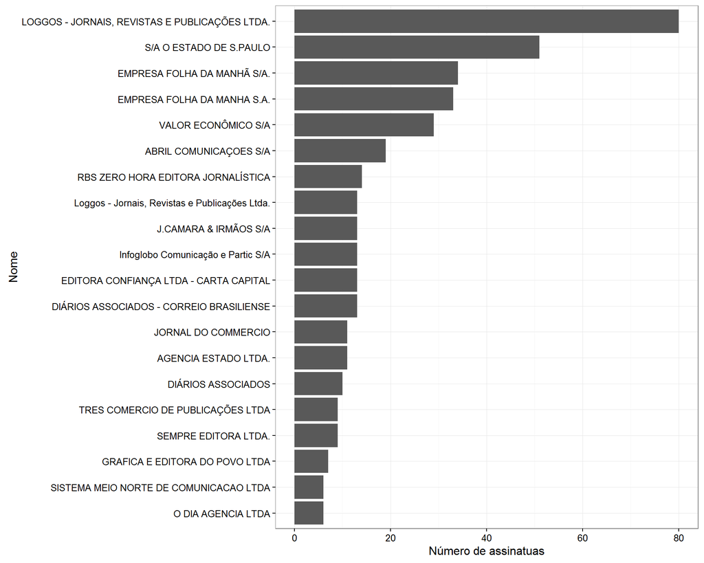

### Agora, quantas assinaturas cada partido realizou?

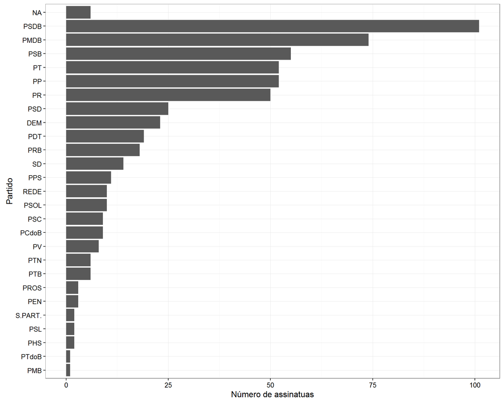

### Qual o fornecedor mais assinado por partido?

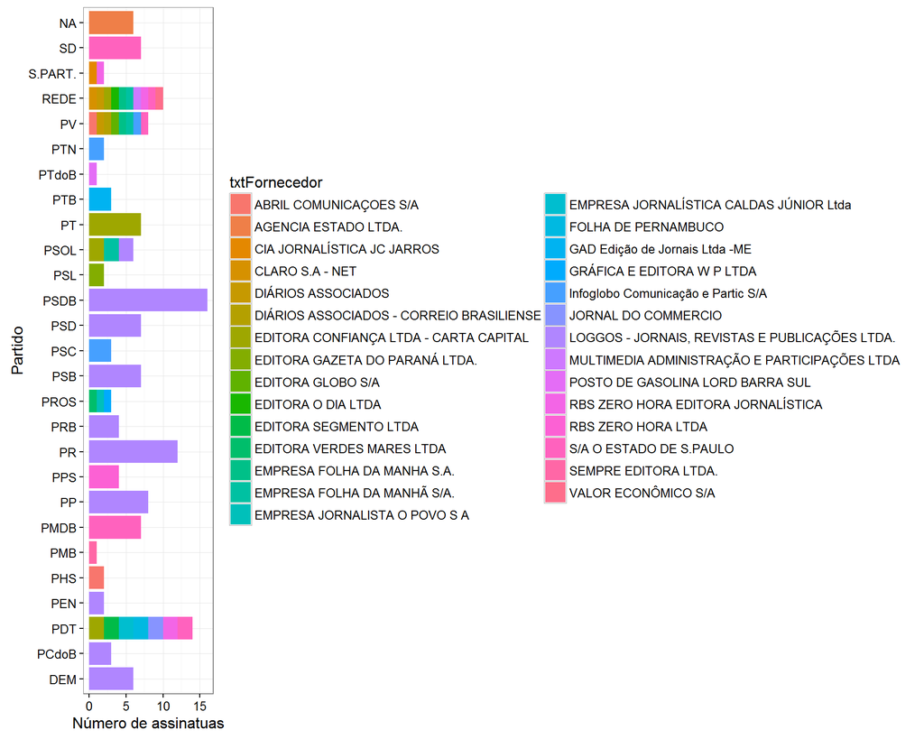

### Agora observamos apenas os partidos mais bem definidos por tipo de assinatura (partidos em que não há empate de fornecedor mais assinado):

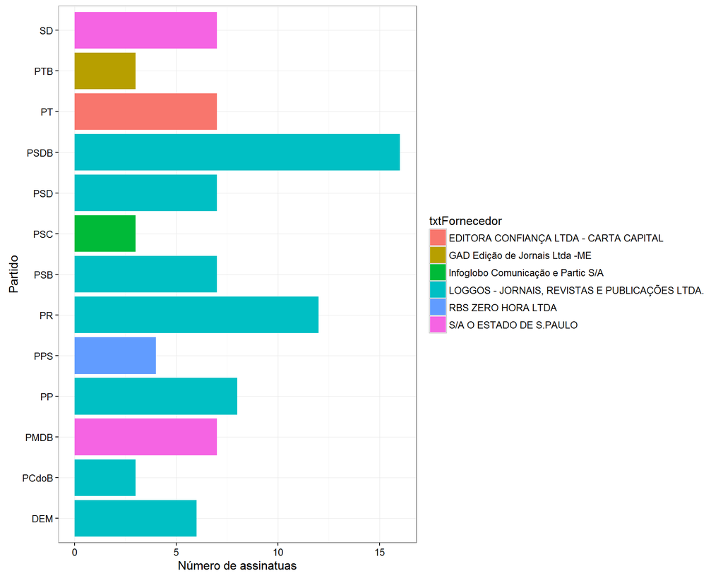

### Dos partidos mais bem definidos, agora observamos os partidos únicos por preferência de fornecedor(partidos em que não há nenhum outro com a mesma preferência)

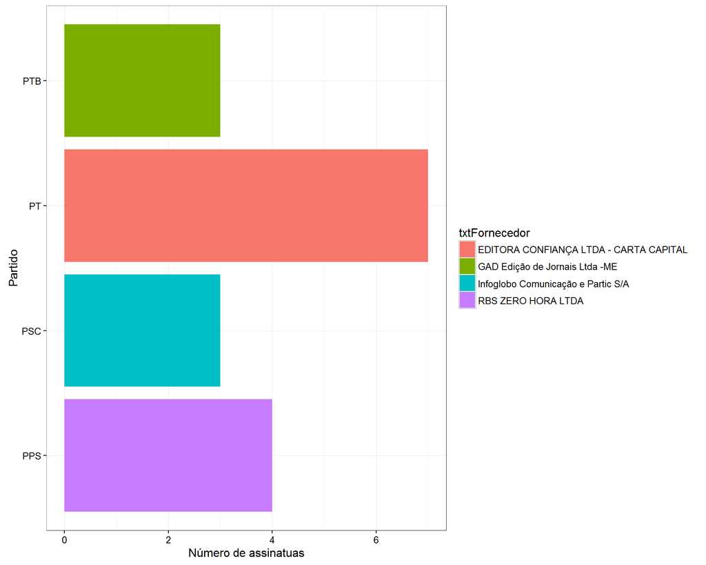

#### Observando os partidos mais bem definidos acima, e tendo o conhecimento dos fornecedores em questão, podemos dizer que é possivel determinar o posicionamento político de um partido a partir das publicações assinadas. Por exemplo a Editora Confiança LTDA e a RBS Zero Hora LTDA, tem posicionamento mais pró-governo (PT). Já o Infoglobo Comunicação e Participações S/A, tem posicionamento mais contrário ao governo.

### E quem são esses fornecedores?

#### Editora Confiança LTDA. Fundada em 2001. Revistas: Carta Capital, Carta na Escola e Carta Fundamental

#### GAD Edição de Jornais LTDA - ME. Fundada em 2011. Jornal Vizão Carazinhense (Carazinho-RS)

#### Infoglobo Comunicação e Participação S/A. Fundada em 1925. Jornais: O Globo, Extra, Expresso.

#### RBS Zero Hora. Fundada em 1964. Jornal: Zero Hora